# About probability distributions

Sandrine Charles

2023-10-24

This page gives some details about the log-logistic and the log-normal probability distributions as proposed for SSD analyses in MOSAIC. These two distributions are the most use by ecotoxicologists in practice. Both are continuous probability distributions.

# Log-normal distribution

The log-normal distribution applies for non-negative random variables whose logarithm is normally distributed. Thus, if the random variable $X$ is log-normally distributed, then $Y = \ln(X)$ has a normal distribution. Similarly, if $Y$ has a normal distribution, then $X = e^Y$ has a log-normal distribution.

A log-normal distribution is characterised by two parameters, $\mu \in [-\infty;+\infty]$ and $\sigma^2 > 0$ whose values are influencing the curve shape. Below, Fig.1 shows the probability density curves for a fixed value of $\mu = 0$ and increasing $\sigma$ values, while Fig.2 shows the corresponding cumulative distribution functions for the same parameter values.

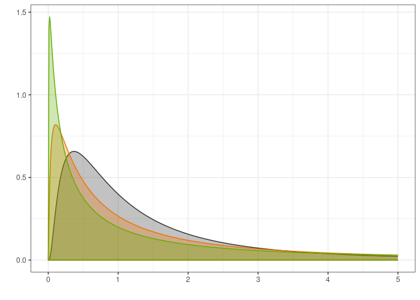

Fig.1: Probability density curves of log-normal distributions with mu = 0 and incresing values of sigma: 1 (dark gray curve), 1.5 (orange (orange curve) and 2 (green curve)

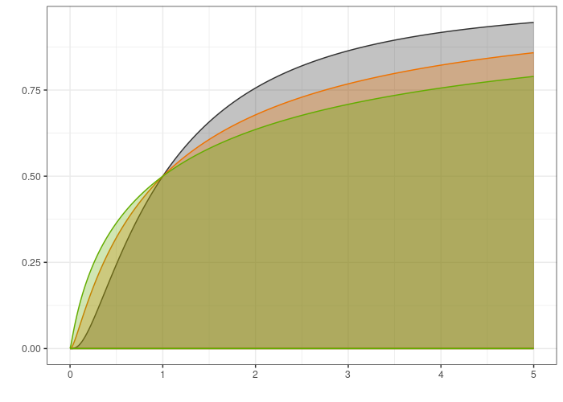

Fig.2: Cumulative distribution functions of a log-normal distribution with a mean equal to 0 and incresing values of sigma: 1 (dark gray curve), 1.5 (orange (orange curve) and 2 (green curve)

# Log-logistic distribution

The log-logistic distribution applies for non-negative random variables whose logarithm has a logistic distribution. It is similar in shape to the log-normal distribution but has heavier tails.

A log-logistic distribution is characterised by two parameters: $\alpha > 0$, corresponding to the median (also called the scale), and $\beta > 0$ the shape. Below, Fig.3 shows the probability density curves for a fixed value of $\alpha = 1$ and increasing $\beta$ values, while Fig.4 shows the corresponding cumulative distribution functions for the same parameter values.

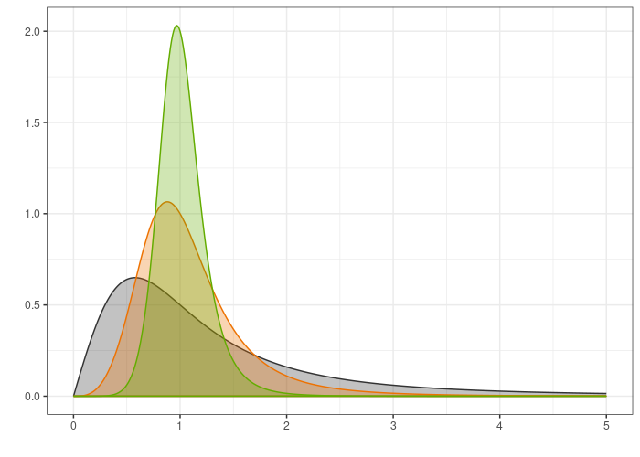

Fig.3: Probability density curves of log-logistic distributions with alpha = 1 and incresing values of beta: 2 (dark gray curve), 4 (orange (orange curve) and 8 (green curve)

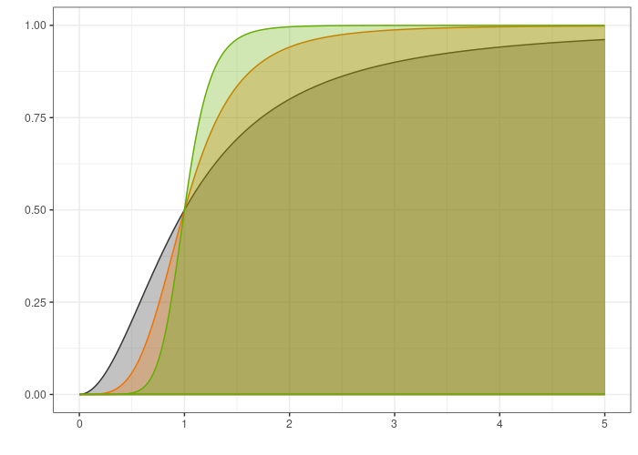

Fig.4: Cumulative distribution functions of log-logistic distributions with alpha = 1 and incresing values of beta: 2 (dark gray curve), 4 (orange (orange curve) and 8 (green curve)

# Log-normal versus log-logistic

Fig. 5 below shows the comparison of cumulative distribution functions of the log-normal and the log-logistic distributions, both distributions having the same mean ($\mu = \frac{1}{2}$) and the same variance ($\sigma^2 = \frac{1}{\pi}-\frac{1}{4}$).

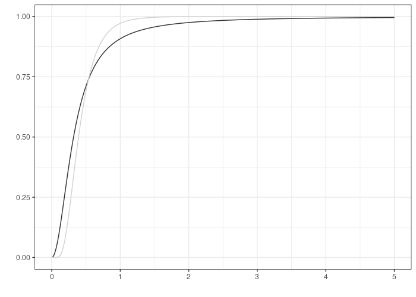

Fig.5: Comparison of cumulative distribution functions of the log-normal (light gray curve) and the log-logistic (dark gray curve) distributions.